# Phase 5 — Covariate Model (Body Weight)

Allometric weight effect on clearance and volume

Author

Pramod BR

Published

June 28, 2026

## 1 Objectives

The IIV model (Phase 4) left between-subject variability as purely *random*. Here we test whether **body weight** explains part of it, by adding an **allometric** weight effect on clearance and volume. The questions: does it improve the fit, and does the random IIV on CL/V shrink?

## 2 How weight enters the model

We use the pharmacometric-standard **allometric** form, normalised to a 70 kg reference, with the exponents estimated from the data (started at the theoretical 0.75 for CL and 1.0 for V):

$$CL = CL_{typ}\,(WT/70)^{\theta_{CL}}, \qquad V = V_{typ}\,(WT/70)^{\theta_{V}}$$

The fitted model’s structure is shown as equations in the next section.

## 3 Fit the covariate model

```r
dat     <- build_nonmem_data()
iiv_fit <- load_iiv_fit()
cov_fit <- fit_cov_model(dat)
```

$$\begin{align*}
{ka} & = \exp\left({tka}+{eta.ka}\right) \\
{cl} & = \exp\left({tcl}+{eta.cl}\right) {\times} {\left(\frac{{WT}}{{70}}\right)}^{{dWTCL}} \\
{v} & = \exp\left({tv}+{eta.v}\right) {\times} {\left(\frac{{WT}}{{70}}\right)}^{{dWTV}} \\
\frac{d \: depot}{dt} & = -{ka} {\times} {depot} \\
\frac{d \: center}{dt} & = {ka} {\times} {depot}-\left(\frac{{cl}}{{v}}\right) {\times} {center} \\
{cp} & = \frac{{center}}{{v}} \\
{cp} & \sim add({add.sd})+prop({prop.sd})
\end{align*}$$

## 4 Parameter estimates

The two new parameters are **dWTCL** and **dWTV** — the weight exponents. Their 95% confidence intervals tell us whether the effect is distinguishable from zero (no effect).

```r
base_param_table(cov_fit) |>
  kbl(caption = "Covariate model estimates (note dWTCL, dWTV exponents)",
      digits = 3) |>
  kable_styling(bootstrap_options = c("striped", "hover", "condensed"),
                full_width = FALSE)
```

Covariate model estimates (note dWTCL, dWTV exponents)

| Parameter | Est. | SE | %RSE | Back-transformed(95%CI) | BSV(CV%) | Shrink(SD)% |
| --- | --- | --- | --- | --- | --- | --- |
| tka | 0.398 | 0.243 | 61.1 | 1.49 (0.924, 2.4) | 72.3 | 2.32%< |
| tcl | 1.03 | 0.0325 | 3.16 | 2.79 (2.62, 2.98) | 26.1 | 3.32%< |
| tv | 3.47 | 0.0984 | 2.84 | 32.1 (26.5, 39) | 10.9 | 22.1%= |
| dWTCL | 0.349 | 0.525 | 151 | 0.349 (-0.68, 1.38) |  |  |
| dWTV | 0.586 | 0.273 | 46.6 | 0.586 (0.0505, 1.12) |  |  |
| add.sd | 0.265 |  |  | 0.265 |  |  |
| prop.sd | 0.134 |  |  | 0.134 |  |  |

## 5 Is the weight effect justified?

```r
cmp <- compare_models(
  model_metrics(iiv_fit, "IIV (no covariate)"),
  model_metrics(cov_fit, "Weight on CL & V")
)
cmp |>
  kbl(caption = "IIV vs covariate model", digits = 2) |>
  kable_styling(bootstrap_options = c("striped", "hover", "condensed"),
                full_width = FALSE)
```

IIV vs covariate model

| Model | OFV | AIC | BIC | nPar | dOFV | dAIC |
| --- | --- | --- | --- | --- | --- | --- |
| IIV (no covariate) | 104.36 | 362.96 | 386.02 | 8 | 0.00 | 0.00 |
| Weight on CL & V | 100.71 | 363.31 | 392.14 | 10 | -3.65 | 0.35 |

Adding two parameters is significant (p < 0.05) if the OFV drops by more than **5.99**. Here ΔOFV = **-3.65**, so on the likelihood-ratio test the weight effect is **not clearly supported** in this dataset.

## 6 Did the random IIV shrink?

If weight genuinely drives part of the between-subject variability, the BSV(CV%) on CL and V should be smaller in the covariate model than in the IIV model.

```r
dplyr::full_join(
  iiv_cv(iiv_fit) |> dplyr::rename(`IIV model` = `BSV CV%`),
  iiv_cv(cov_fit) |> dplyr::rename(`Covariate model` = `BSV CV%`),
  by = "Parameter"
) |>
  kbl(caption = "Between-subject CV% before vs after adding weight",
      digits = 1) |>
  kable_styling(bootstrap_options = c("striped", "hover", "condensed"),
                full_width = FALSE)
```

Between-subject CV% before vs after adding weight

| Parameter | IIV model | Covariate model |
| --- | --- | --- |
| tka | 68.8 | 72.3 |
| tcl | 25.7 | 26.1 |
| tv | 12.6 | 10.9 |

## 7 Residual random effects vs weight

After including weight, the random effects on CL and V should show little residual trend with weight — a flat line means the covariate has absorbed the size effect.

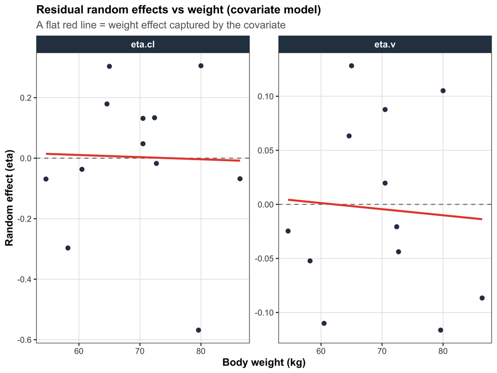

Random effects on CL and V vs body weight in the covariate model.

```r
cov_plot_eta_wt(cov_fit, dat)
```

## 8 Key takeaways

- Body weight was added **allometrically** on CL and V, with estimated exponents.
- On the likelihood-ratio test the effect was **not clearly supported** (ΔOFV = -3.65).
- We reported the change in random CV% and the residual η–weight trend honestly — in a small, weight-dosed dataset like Theoph a strong weight signal is not guaranteed, and recognising that is part of sound covariate analysis.